# 爬民政部官网_行政区域代码

李誉辉

2020年2月21日

**简介：**

通过爬取民政部官网的行政区域代码，  
为今后爬取县级地图数据做准备。

# 1 需要的包

```r
rm(list = ls()); gc() # 清空内存
library(tibble)
library(dplyr)
library(purrr)
library(magrittr)
library(rvest)
library(stringr)
library(tidyr)
```

```
##           used (Mb) gc trigger (Mb) max used (Mb)
## Ncells  524864 28.1    1188784 63.5   621654 33.2
## Vcells 1005522  7.7    8388608 64.0  1600121 12.3
```

# 2 爬行政区域代码

首先打开 [民政部官网](http://xzqh.mca.gov.cn/map)，如下：

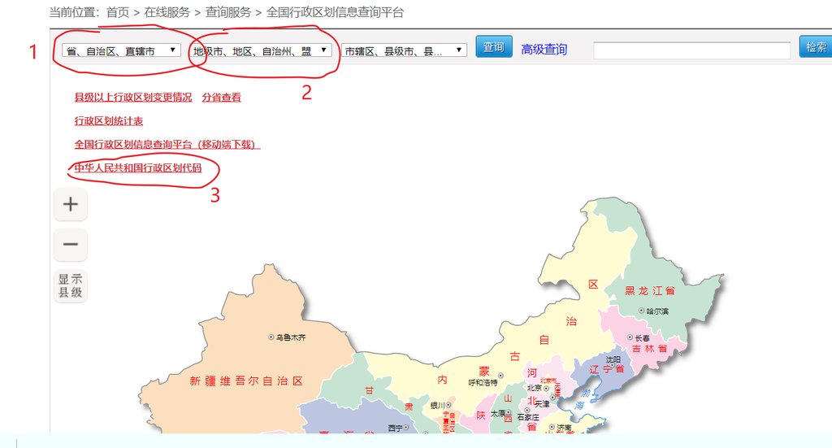

点击上图中的“3”。  
里面有最新的行政区域代码公示，

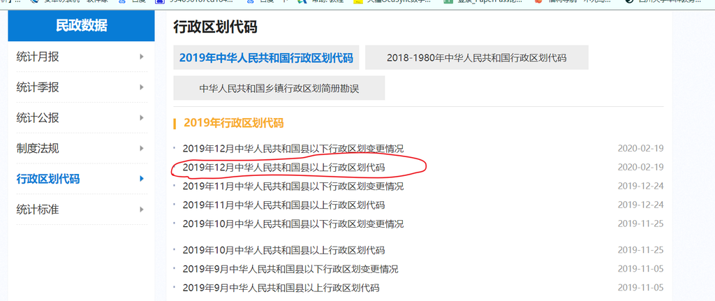

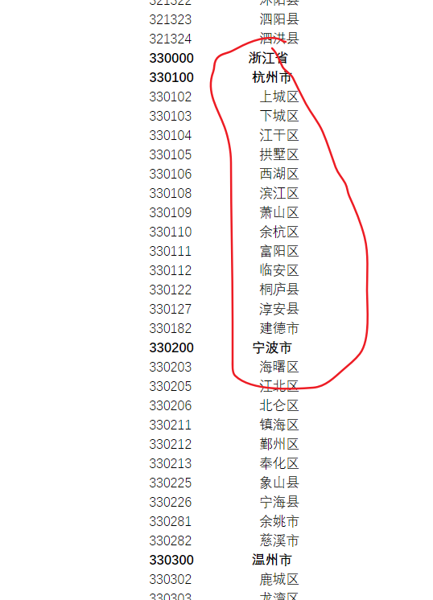

然后使用爬虫爬取。  
需要注意的是，该表缺乏台湾、香港、澳门3个地区的区县信息。  
使用 [SelectorGadget](https://chrome.google.com/webstore/detail/selectorgadget/mhjhnkcfbdhnjickkkdbjoemdmbfginb)插件, 很容易发现“市级行政区域”的`class`是`.x17214735`;  
而“县级行政区域”的`class`是`.x17314735`。

# 3 访问网页

```r
url_allCode <- "http://www.mca.gov.cn/article/sj/xzqh/2019/2019/202002191838.html"
html_allCode <- read_html(x = url_allCode)

xian_allCode <- html_nodes(x = html_allCode, css = ".xl7314735") %>%
  map(html_text) %>% unlist()

shi_allCode <- html_nodes(x = html_allCode, css = ".xl7214735") %>%
  map(html_text) %>% unlist()
```

# 4 文本处理

提取的文本，还需要将行政区域代码和行政区域名字分开，  
然后使用正则表达式删掉异常字符。

```r
# 分开代码和名字
xian_code_df <-  tibble(code = xian_allCode[seq(1, length(xian_allCode), by = 2)],
                        xian = xian_allCode[seq(2, length(xian_allCode), by = 2)]) %>%
  # 正则表达式
  mutate(xian2 = str_extract_all(xian, "[\u4e00-\u9fa5]+")) %>%
  select(code_x = code, xian = xian2) %>%
  unnest()

shi_code_df <- tibble(code = shi_allCode[seq(1, length(shi_allCode), by = 2)],
                      shi = shi_allCode[seq(2, length(shi_allCode), by = 2)]) %>%
  mutate(shi2 = str_extract_all(shi, "[\u4e00-\u9fa5]+")) %>%
  select(code_s = code, shi = shi2) %>%
  unnest()

# 查看首尾，与网页对比
head(xian_code_df)
tail(xian_code_df)
head(shi_code_df)
tail(shi_code_df)
```

| code_x | xian |
| --- | --- |
| 110101 | 东城区 |
| 110102 | 西城区 |
| 110105 | 朝阳区 |
| 110106 | 丰台区 |
| 110107 | 石景山区 |
| 110108 | 海淀区 |

| code_x | xian |
| --- | --- |
| 659005 | 北屯市 |
| 659006 | 铁门关市 |
| 659007 | 双河市 |
| 659008 | 可克达拉市 |
| 659009 | 昆玉市 |
| 659010 | 胡杨河市 |

| code_s | shi |
| --- | --- |
| 110000 | 北京市 |
| 120000 | 天津市 |
| 130000 | 河北省 |
| 130100 | 石家庄市 |
| 130200 | 唐山市 |
| 130300 | 秦皇岛市 |

| code_s | shi |
| --- | --- |
| 654000 | 伊犁哈萨克自治州 |
| 654200 | 塔城地区 |
| 654300 | 阿勒泰地区 |
| 710000 | 台湾省 |
| 810000 | 香港特别行政区 |
| 820000 | 澳门特别行政区 |

# 5 数据归并

前面的数据，省级和市级代码是并列的，现在需要将其归并。  
我们观察到行政区域代码共6位，  
前2位是省级、直辖市、特区代码。  
省级行政区域后4位全为0。  
县级代码与所在市代码前3位均相同，  
遂通过这种方式归类。  
最终将省、市和县级代码全部归并。

## 5.1 归并省市

```r
shi_code_df2 <- shi_code_df %>% mutate(c1 = substr(code_s, 1, 2),
                                       c2 = substr(code_s, 3, 6))

sheng_code <- shi_code_df2 %>% filter(c2 == "0000") %>%
  select(sheng = shi, code_she = code_s, c1)

# 特区和直辖市
special_code <- sheng_code %>% mutate(s2 = substr(sheng, 1, 2)) %>%
  filter(s2 %in% c("北京", "上海", "天津", "重庆", "香港", "澳门", "台湾")) %>%
  select(shi = sheng, code_s = code_she, c1)

# 归并省市
sheng_shi_code <- shi_code_df2 %>% filter(c2 != "0000") %>%
  select(shi, code_s, c1) %>%
  rbind(special_code) %>%
  left_join(sheng_code, by = "c1") %>%
  select(sheng, code_she, shi, code_s) %>%
  arrange(code_she, code_s)

# 保存数据到文件
file_pre <- "E:/R_input_output/data_input/xian_China"
write.csv(sheng_shi_code, row.names = FALSE,
          file = paste(file_pre, "sheng_shi_code.csv", sep = "/"))

# 动态表格展示
DT::datatable(sheng_shi_code)
```

|  | sheng | code_she | shi | code_s |
| --- | --- | --- | --- | --- |
| 1 | 北京市 | 110000 | 北京市 | 110000 |
| 2 | 天津市 | 120000 | 天津市 | 120000 |
| 3 | 河北省 | 130000 | 石家庄市 | 130100 |
| 4 | 河北省 | 130000 | 唐山市 | 130200 |
| 5 | 河北省 | 130000 | 秦皇岛市 | 130300 |
| 6 | 河北省 | 130000 | 邯郸市 | 130400 |
| 7 | 河北省 | 130000 | 邢台市 | 130500 |
| 8 | 河北省 | 130000 | 保定市 | 130600 |
| 9 | 河北省 | 130000 | 张家口市 | 130700 |
| 10 | 河北省 | 130000 | 承德市 | 130800 |

[output cut: 330 more lines]

## 5.2 归并县市

```r
sheng_shi_code2 <- sheng_shi_code %>% mutate(c3 = substr(code_s, 1, 3))
sheng_shi_xian <- xian_code_df %>% mutate(c3 = substr(code_x, 1, 3)) %>%
  full_join(sheng_shi_code2, by = "c3") %>%
  select(sheng, code_she, shi, code_s, xian, code_x) %>%
  arrange(code_she, code_s, code_x)

# 保存到本地文件
write.csv(sheng_shi_xian, row.names = FALSE,
          file = paste(file_pre, "sheng_shi_xian_code.csv", sep = "/"))
```

**手动校正：**  
记事本打开，发现新增了很多区县是后来增加的，并不符合命名规律，于是手动校准：

- 4690开头的属于460400儋州市
- 4190开头的济源市属于411700 驻马店市
- 4290开头的属于422800恩施土家族苗族自治州
- 6590开头的都属于654300阿勒泰地区

```r
abnornal_code <- tibble(c4 = as.character(c(4190, 4290, 4690, 6590)),
                        code_s = as.character(c(411700, 422800, 460400, 654300)))
xian_abnornal <- sheng_shi_xian %>% filter(is.na(code_s)) %>%
  select(-code_s) %>%
  mutate(c4 = substr(code_x, 1, 4)) %>%
  left_join(abnornal_code, by = "c4") %>%
  select(code_s, xian, code_x)

sheng_shi_xian_abnornal <- sheng_shi_xian %>%
  filter(code_s %in% abnornal_code$code_s) %>%
  distinct(code_s, .keep_all = TRUE) %>%
  select(-xian, -code_x) %>%
  right_join(xian_abnornal, by = "code_s") %>%
  select(sheng, code_she, shi, code_s, xian, code_x)

sheng_shi_xian2 <- sheng_shi_xian %>% filter(!is.na(code_s)) %>%
  rbind(sheng_shi_xian_abnornal) %>%
  arrange(code_she, code_s, code_x)

# 保存到本地文件
write.csv(sheng_shi_xian2, row.names = FALSE,
          file = paste(file_pre, "sheng_shi_xian_code.csv", sep = "/"))

# 动态表格展示
DT::datatable(sheng_shi_xian2)
```

|  | sheng | code_she | shi | code_s | xian | code_x |
| --- | --- | --- | --- | --- | --- | --- |
| 1 | 北京市 | 110000 | 北京市 | 110000 | 东城区 | 110101 |
| 2 | 北京市 | 110000 | 北京市 | 110000 | 西城区 | 110102 |
| 3 | 北京市 | 110000 | 北京市 | 110000 | 朝阳区 | 110105 |
| 4 | 北京市 | 110000 | 北京市 | 110000 | 丰台区 | 110106 |
| 5 | 北京市 | 110000 | 北京市 | 110000 | 石景山区 | 110107 |
| 6 | 北京市 | 110000 | 北京市 | 110000 | 海淀区 | 110108 |
| 7 | 北京市 | 110000 | 北京市 | 110000 | 门头沟区 | 110109 |
| 8 | 北京市 | 110000 | 北京市 | 110000 | 房山区 | 110111 |
| 9 | 北京市 | 110000 | 北京市 | 110000 | 通州区 | 110112 |
| 10 | 北京市 | 110000 | 北京市 | 110000 | 顺义区 | 110113 |

[output cut: 17728 more lines]

# 6 敬请期待

后续将通过爬取的行政区域代码，  
与爬取地图数据结合，生成有行政区域代码的地图数据，  
并通过层级行政区域代码，计算各级行政区域中心坐标。

**参考来源：**

- 中国县级地图绘制
- [全国行政区划信息查询平台](http://xzqh.mca.gov.cn/map)
- 浙江行政区域代码表格
- [2019年12月中华人民共和国县以上行政区划代码](http://www.mca.gov.cn/article/sj/xzqh/2019/2019/202002191838.html)
- [百度地图坐标拾取系统](http://api.map.baidu.com/lbsapi/getpoint/index.html)
- [计算行政区域中心坐标](https://gis.stackexchange.com/questions/43543/how-to-calculate-polygon-centroids-in-r-for-non-contiguous-shapes)
- [行合并sf对象](https://rdrr.io/cran/sf/man/bind.html)
- [高德地图API接口获取经纬度坐标](https://mp.weixin.qq.com/s/2DawZWjlT1jxbs7GM0DLVg)